# Programowanie w R: Projekt - Analiza materiałów wykorzystywanych w produkcji baterii

# Analiza danych

## Znajdowanie korelacji

```r
correlation_matrix <- cor(numeric_cols, use = "complete.obs")
prettyTable(as.data.frame(correlation_matrix), 2, 100, TRUE)
```

|  | Max.Delta.Volume | Average.Voltage | Gravimetric.Capacity | Volumetric.Capacity | Gravimetric.Energy | Volumetric.Energy | Atomic.Fraction.Charge | Atomic.Fraction.Discharge | Stability.Charge | Stability.Discharge | Steps | Max.Voltage.Step |
| --- | --- | --- | --- | --- | --- | --- | --- | --- | --- | --- | --- | --- |
| Max.Delta.Volume | 1 | -0.07758575452485697 | 0.4337733489596478 | 0.2424769202909113 | -0.04515636651571633 | -0.04917987958023858 | 0.02131530419502814 | 0.290692091931251 | 0.03375865003862862 | 0.007735655156223099 | -0.01325821373855603 | -0.00992514540500106 |
| Average.Voltage | -0.07758575452485697 | 1 | -0.1548880812353321 | -0.2285573635276998 | 0.6400671705724741 | 0.5209277030568776 | -0.04684010934080857 | -0.1599257105422043 | 0.2330895817097972 | -0.03823568607728008 | 0.05529010919216379 | 0.1267048707676187 |
| Gravimetric.Capacity | 0.4337733489596478 | -0.1548880812353321 | 1 | 0.8584162667298963 | 0.2507138878904345 | 0.2567643726269383 | 0.1289210105641614 | 0.6807716411772927 | 0.06338705331869193 | 0.01253898350314075 | 0.1333976550079053 | 0.09519064518707779 |
| Volumetric.Capacity | 0.2424769202909113 | -0.2285573635276998 | 0.8584162667298963 | 1 | 0.2348584122222026 | 0.3522958362946269 | 0.001245629891621591 | 0.6180186046012928 | 0.1015304879141566 | 0.03170121316543634 | 0.1037051173710295 | 0.06260853327660702 |
| Gravimetric.Energy | -0.04515636651571633 | 0.6400671705724741 | 0.2507138878904345 | 0.2348584122222026 | 1 | 0.9239725337523782 | -0.1059514202173037 | 0.1297046921728934 | 0.1953855988496985 | -0.02260355009278204 | 0.2952305795925688 | 0.3337496437471327 |
| Volumetric.Energy | -0.04917987958023858 | 0.5209277030568776 | 0.2567643726269383 | 0.3522958362946269 | 0.9239725337523782 | 1 | -0.1569356230984077 | 0.1056131683879409 | 0.2026379278957944 | -0.01224778712706153 | 0.2372767671259796 | 0.2548273875366792 |
| Atomic.Fraction.Charge | 0.02131530419502814 | -0.04684010934080857 | 0.1289210105641614 | 0.001245629891621591 | -0.1059514202173037 | -0.1569356230984077 | 1 | 0.5974157470183368 | -0.02735713773278817 | -0.05239708784421818 | 0.02973691166605371 | 0.005342003285918124 |
| Atomic.Fraction.Discharge | 0.290692091931251 | -0.1599257105422043 | 0.6807716411772927 | 0.6180186046012928 | 0.1297046921728934 | 0.1056131683879409 | 0.5974157470183368 | 1 | 0.03240510371003 | 0.01432038543905589 | 0.1641712958458394 | 0.1019796449372943 |
| Stability.Charge | 0.03375865003862862 | 0.2330895817097972 | 0.06338705331869193 | 0.1015304879141566 | 0.1953855988496985 | 0.2026379278957944 | -0.02735713773278817 | 0.03240510371003 | 1 | 0.8028700951198852 | -0.0374859862898957 | 0.09404656773346405 |
| Stability.Discharge | 0.007735655156223099 | -0.03823568607728008 | 0.01253898350314075 | 0.03170121316543634 | -0.02260355009278204 | -0.01224778712706153 | -0.05239708784421818 | 0.01432038543905589 | 0.8028700951198852 | 1 | -0.06316864536660587 | -0.01655517630145012 |

[output cut: 2 more lines]

```r
correlation_df <-
  correlation_matrix %>%
  as.table() %>%
  as.data.frame() %>%
  rename(Correlation = Freq)

correlation_df %>%
  filter(as.character(Var1) > as.character(Var2)) %>%
  arrange(desc(abs(Correlation))) %>%
  head(5) %>%
  prettyTable()
```

| Var1 | Var2 | Correlation |
| --- | --- | --- |
| Volumetric.Energy | Gravimetric.Energy | 0.9239725337523782 |
| Volumetric.Capacity | Gravimetric.Capacity | 0.8584162667298963 |
| Stability.Discharge | Stability.Charge | 0.8028700951198852 |
| Gravimetric.Capacity | Atomic.Fraction.Discharge | 0.6807716411772927 |
| Gravimetric.Energy | Average.Voltage | 0.6400671705724741 |

## Pojemność i Energia baterii

Grawimetryczna energia i pojemność to kluczowe wskaźniki służące do oceny wydajności baterii. Chociaż są ze sobą powiązane, odnoszą się do różnych właściwości:

**Grawimetryczna gęstość energii (Wh/kg)** to ilość energii, jaką bateria może przechowywać na jednostkę masy. Uwzględnia zarówno pojemność, jak i nominalne napięcie baterii, odzwierciedlając całkowitą dostępną energię.

$$\text{Gravimetric Energy
Density}\left[\frac{\text{Wh}}{\text{kg}}\right] = \frac{\text{Voltage}
\times \text{Capacity}}{\text{Weight}}$$

**Grawimetryczna pojemność (Ah/kg)**, czyli całkowity ładunek, jaki bateria może przechować na jednostkę masy. Koncentruje się wyłącznie na ilości przechowywanego ładunku, niezależnie od napięcia.

$$\text{Gravimetric Capacity}\left[\frac{\text{Ah}}{\text{kg}}\right] =
\frac{\text{Capacity}}{\text{Weight}}$$

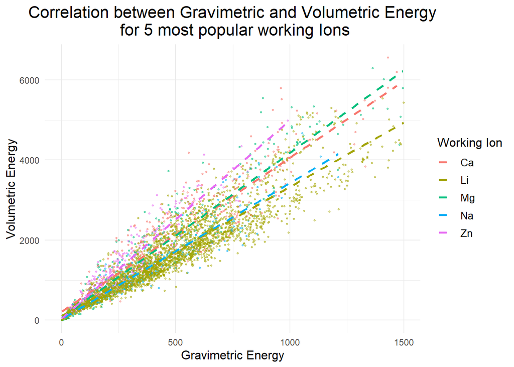

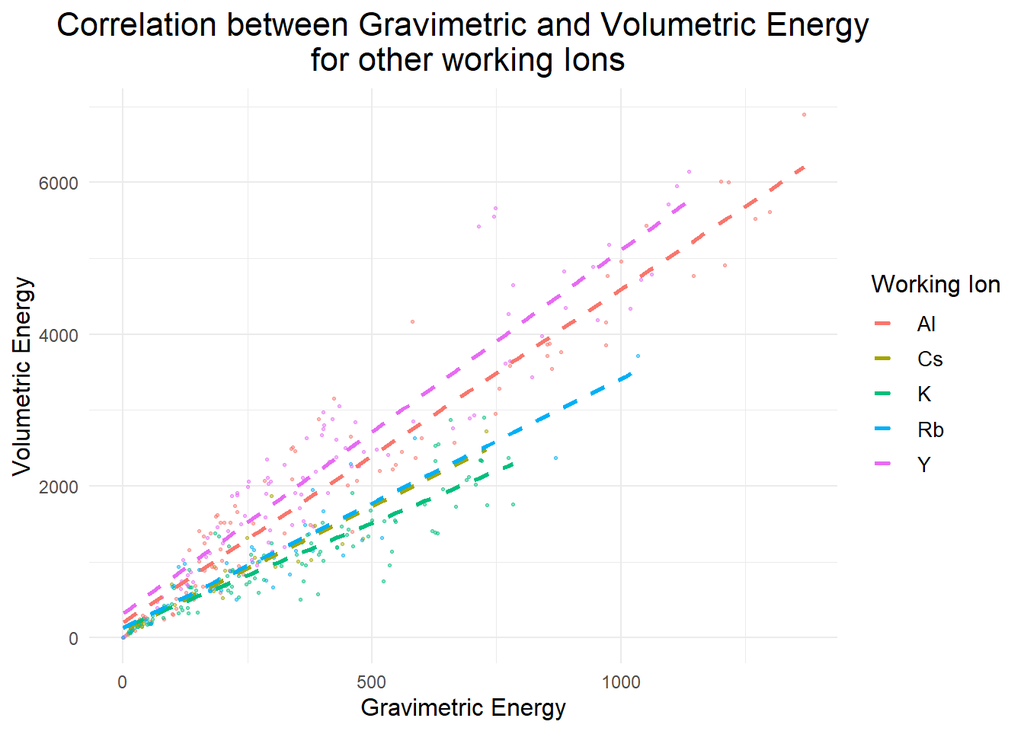

## Model for predicting Average.Voltage from other parameters

```r
train_indices <- createDataPartition(numeric_cols$Average.Voltage, p = 0.7, list = FALSE)
data_train <- numeric_cols[train_indices, ]
data_test <- numeric_cols[-train_indices, ]

## linear model:
# model <- lm(Average.Voltage ~ ., data = data_train)
## random forest
ctrl <- trainControl(
    method = "repeatedcv", # repeated cross validation
    number = 2,
    repeats = 5)
model <- train(Average.Voltage ~ .,
             data = data_train,
             method = "rf",
             trControl = ctrl,
             ntree = 10)
# Summary of the model
# summary(model)

predictions <- predict(model, newdata = data_test)

actual <- data_test$Average.Voltage
mae <- mean(abs(predictions - actual))  # Mean Absolute Error
mse <- mean((predictions - actual)^2)   # Mean Squared Error
rmse <- sqrt(mse)                       # Root Mean Squared Error


print(paste(
  "Mean Absolute Error:", mae,
  "Mean Squared Error:", mse,
  "Root Mean Squared Error:", rmse
))
```

```
## [1] "Mean Absolute Error: 0.148947880260418 Mean Squared Error: 0.22469047959958 Root Mean Squared Error: 0.474015273593141"
```

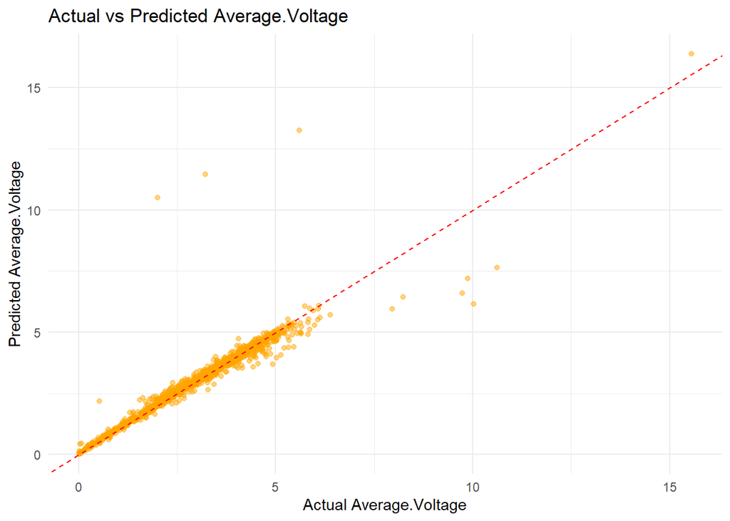

```r
# Plot actual vs predicted values
ggplot(data.frame(actual, predictions), aes(x = actual, y = predictions)) +
  geom_point(alpha = 0.5, color= "orange") +
  geom_abline(slope = 1, intercept = 0, color = "red", linetype = "dashed") +
  labs(title = "Actual vs Predicted Average.Voltage",
       x = "Actual Average.Voltage",
       y = "Predicted Average.Voltage") +
  theme_minimal()
```